# Exploratory analyses: relationships in the file drawer survey

This document is **hypothesis-generating**. It searches for potentially interesting relationships:

- between *demographic/career variables* (D*) and* variables of interest* (R*, I*, S*, H*, M*)
- among *variables of interest* (e.g., awareness → uptake; barriers → uptake)

Given the small sample size (N = 50) and many possible comparisons, treat results as *exploratory signals*, not confirmatory evidence.

**Reading guide (how to interpret the output in this report)**

- Many sections output a table with columns like `n`, `rho`, `p`, `p_adj`.
  - `rho` is a **Spearman rank correlation** (monotonic association) between one predictor and one outcome.
  - `n` is the number of respondents with **non-missing values in both variables** (complete-case for that pair).
  - `p` is the nominal p-value from `cor.test(..., method = "spearman")`.
  - `p_adj` is a **Benjamini–Hochberg (BH) false-discovery-rate adjustment** applied *within that table* (i.e., within that “screen” of many pairwise tests).
- When variables are binary (0/1) or counts, Spearman correlations are still defined; interpret them as rank/monotonic effects (not linear regression slopes).
- For any correlation, the report enforces `min_n = 10`; if fewer than 10 complete cases exist, the correlation is not computed.

# Helpers (tables, plots, recoding)

This section defines helper functions used throughout the report:

- `recode_*()` functions convert Qualtrics-style string responses into numeric scales (e.g., S5 Likert → 1–5).
- `spearman_test()` computes one Spearman correlation for a given X–Y pair.
- `screen_spearman()` runs **many** Spearman correlations across all X–Y pairs you specify, then BH-adjusts the p-values within that screen.
- `plot_spearman()` draws a scatterplot with a fitted line and prints Spearman correlation in the panel.

# Data + derived variables

**What happens in this section**

1. Load the public survey dataset `data_public/public_main.csv` into `results_raw`.
2. Define label dictionaries (e.g., what each `S5[SQ00x]` stands for) so later tables are readable.
3. Create a cleaned `results` data frame with:
   - numeric versions of ordinal items (e.g., S5, S6, H4, I5),
   - a small set of *derived indices* used repeatedly in EDA (e.g., attrition share, open-science uptake),
   - convenience demographic variables (e.g., `career_stage_ord`).

**Key derived variables used below (plain-language definitions)**

- **Demographics / productivity**
  - `years_active` = D3 (years active in experimental philosophy)
  - `methods_courses` = D5 (number of methods/statistics courses)
  - `projects_per_year` = D9, `pub_per_year` = D10, `quant_projects_per_year` = D11
  - `career_stage_ord` is an ordinal recode of D7 (Graduate student = 1 … Full professor = 5); `early_career = 1` if `career_stage_ord <= 3`
- **Attrition / file-drawer exposure (from R1 stage counts)**
  - `published_n` = R1[SQ006]
  - `attrition_pre_sub_n` = R1[SQ001] + R1[SQ002] + R1[SQ003] (data analysis + formal + professional presentation)
  - `attrition_post_sub_n` = R1[SQ004] + R1[SQ005] (submitted + reviewed manuscript)
  - `attrition_total_n` = `attrition_pre_sub_n + attrition_post_sub_n`
  - `attrition_share` = `attrition_total_n / (attrition_total_n + published_n)` when denominator > 0
- **Awareness / implications**
  - `I2_num` is extracted from the I2 response string (e.g., `"5 - Very familiar"` → 5)
  - `I4_familiarity_mean` is the mean of the 7 familiarity ratings (I4[…][1])
  - `I4_severity_mean` is the mean of the 7 severity ratings (I4[…][2])
- **Barriers / incentives / capacity**
  - `barriers_mean` = mean of 11 S5 items after recoding to 1–5 (`Not a reason at all` → 1 … `Extremely a reason` → 5)
  - `incentives_mean` = mean of 5 S6 items after recoding to 1–5
  - `training_need_mean` = mean of 5 H4 items after recoding to 1–5
- **Uptake of proposed solutions**
  - For each S4 item, `"Yes"` → 1, `"No"` → 0, `"I don't know"` → missing.
  - `open_science_present_prop` = proportion of S4 *present* items answered `"Yes"` among the non-missing S4 present items for that respondent.
  - `open_science_future_prop` = analogous proportion for S4 *future*.
  - `fd_practices_present_yes` / `fd_practices_future_yes` = number of `"Yes"` responses for a focused “file-drawer-targeted” subset (registered reports, replications, micropublications).
- **Data sharing / micropublications**
  - `data_shared_ever` is derived from H1: it equals 1 if a respondent selected *any* sharing route (H1[SQ001]–H1[SQ006] = Yes), and 0 if they selected H1[SQ007] (“No”).
  - `micropublications_ord` recodes M1 into 0/1/2 for Never/Rarely/Sometimes.

## Quick descriptive sanity check (key indices)

**What this table is:** a compact descriptive summary of all key variables/indices used in later EDA.  
For binary variables (0/1), the mean is interpretable as the **proportion** of 1s.

| label | n | M | SD |
| --- | --- | --- | --- |
| Years active in experimental philosophy | 50 | 9.14 | 5.27 |
| Published projects | 50 | 6.98 | 9.66 |
| Total attrition | 50 | 4.16 | 5.31 |
| Willingness to change practices | 50 | 4.08 | 0.85 |
| Familiarity with the file drawer problem | 46 | 4.04 | 1.05 |
| Mean unacceptability of questionable research practices | 50 | 3.97 | 0.59 |
| Mean familiarity with consequences | 50 | 3.91 | 0.90 |
| Mean perceived severity of consequences | 50 | 3.61 | 0.63 |
| Attrition before submission | 50 | 3.52 | 4.78 |
| Mean motivating incentives | 50 | 3.46 | 0.90 |
| Mean training need for data sharing | 50 | 3.01 | 1.05 |
| Career stage (ordinal) | 49 | 2.94 | 1.21 |
| Methods/statistics courses completed | 50 | 2.90 | 3.52 |
| Barrier subscale: time/incentives/pressure | 50 | 2.86 | 1.21 |
| Mean barriers to sharing/publishing | 50 | 2.18 | 0.77 |
| Barrier subscale: skills/technical barriers | 50 | 2.14 | 0.92 |
| Projects per year | 50 | 1.95 | 1.76 |
| Barrier subscale: external restrictions/policy | 50 | 1.89 | 0.86 |
| Quantitative projects per year | 50 | 1.83 | 1.72 |
| Institutional supports for open dissemination (count) | 50 | 1.82 | 1.34 |
| Peer-reviewed publications per year | 50 | 1.80 | 1.62 |
| Barrier subscale: defensive concerns (IP/misuse/competition) | 50 | 1.80 | 0.96 |
| Future file-drawer-targeted practices (count) | 50 | 1.46 | 1.03 |
| Sponsor requirements for open dissemination (count) | 50 | 1.38 | 1.40 |
| Ever shared data | 49 | 0.86 | 0.35 |
| Future open-science uptake (proportion) | 50 | 0.81 | 0.18 |
| Early career (student/postdoc/assistant) | 49 | 0.71 | 0.46 |
| Current file-drawer-targeted practices (count) | 50 | 0.66 | 0.82 |
| Attrition at submission/review | 50 | 0.64 | 1.27 |
| Current open-science uptake (proportion) | 50 | 0.47 | 0.25 |
| Attrition share = attrition/(attrition+published) | 46 | 0.45 | 0.35 |
| Micropublications frequency (ordinal) | 50 | 0.22 | 0.51 |

# Exploratory relationships (literature-motivated)

**Common analysis template in Sections 1–4:**  
Each table is a *screen* of multiple pairwise associations computed with `screen_spearman()`:

- statistic: Spearman `rho`
- missingness: complete-case for each pair
- multiplicity: BH/FDR `p_adj` computed **within that table** (not across the whole document)

## 1) Resource constraints (S5) vs uptake (S4)

**Goal:** relate broad constraints and “context” variables to uptake behaviors.

- Predictors (`x_vars`):
  - `barriers_mean` (mean of 11 S5 barrier items; 1–5)
  - `sponsor_req_count` (count of sponsor requirements selected in S1; 0–4)
  - `institution_support_count` (count of institutional supports selected in S2; 0–5)
- Outcomes (`y_vars`):
  - uptake indices: `open_science_present_prop`, `open_science_future_prop`
  - file-drawer-targeted uptake: `fd_practices_present_yes`, `fd_practices_future_yes`
  - dissemination behaviors: `data_shared_ever`, `micropublications_ord`

| x_label | y_label | n | rho | p | p_adj |
| --- | --- | --- | --- | --- | --- |
| Mean barriers to sharing/publishing | Ever shared data | 49 | -0.39 | 0.01 | 0.10 |
| Mean barriers to sharing/publishing | Current open-science uptake (proportion) | 50 | -0.33 | 0.02 | 0.19 |
| Mean barriers to sharing/publishing | Future open-science uptake (proportion) | 50 | -0.28 | 0.05 | 0.28 |
| Mean barriers to sharing/publishing | Micropublications frequency (ordinal) | 50 | -0.25 | 0.07 | 0.28 |
| Sponsor requirements for open dissemination (count) | Current open-science uptake (proportion) | 50 | 0.25 | 0.08 | 0.28 |
| Sponsor requirements for open dissemination (count) | Future open-science uptake (proportion) | 50 | 0.23 | 0.10 | 0.29 |
| Sponsor requirements for open dissemination (count) | Ever shared data | 49 | 0.23 | 0.11 | 0.29 |
| Sponsor requirements for open dissemination (count) | Current file-drawer-targeted practices (count) | 50 | 0.16 | 0.28 | 0.62 |
| Mean barriers to sharing/publishing | Current file-drawer-targeted practices (count) | 50 | -0.15 | 0.31 | 0.62 |
| Mean barriers to sharing/publishing | Future file-drawer-targeted practices (count) | 50 | -0.13 | 0.37 | 0.67 |
| Sponsor requirements for open dissemination (count) | Micropublications frequency (ordinal) | 50 | 0.12 | 0.41 | 0.67 |
| Sponsor requirements for open dissemination (count) | Future file-drawer-targeted practices (count) | 50 | 0.07 | 0.63 | 0.88 |
| Institutional supports for open dissemination (count) | Current file-drawer-targeted practices (count) | 50 | 0.07 | 0.64 | 0.88 |
| Institutional supports for open dissemination (count) | Future open-science uptake (proportion) | 50 | -0.06 | 0.68 | 0.88 |
| Institutional supports for open dissemination (count) | Ever shared data | 49 | 0.04 | 0.78 | 0.90 |
| Institutional supports for open dissemination (count) | Current open-science uptake (proportion) | 50 | -0.03 | 0.82 | 0.90 |
| Institutional supports for open dissemination (count) | Micropublications frequency (ordinal) | 50 | 0.02 | 0.89 | 0.90 |
| Institutional supports for open dissemination (count) | Future file-drawer-targeted practices (count) | 50 | 0.02 | 0.90 | 0.90 |

**Visualization:** scatterplot of `barriers_mean` vs `open_science_present_prop` with a linear smoother for readability; the annotation reports Spearman correlation.

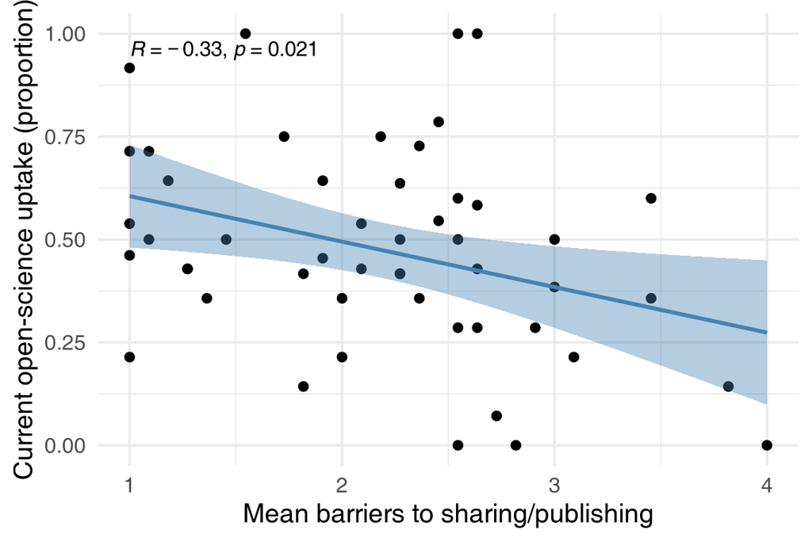

## 1a) Which specific barriers relate to data sharing and uptake?

**Goal:** go from the overall `barriers_mean` index to the **individual S5 items**, to see which barrier types actually drive any associations.

- Predictors (`x_vars`): each of the 11 barrier items `S5[SQ001]`–`S5[SQ011]`, recoded to 1–5:
  - 1 = “Not a reason at all” … 5 = “Extremely a reason”
- Outcomes (`y_vars`):
  - `data_shared_ever` (0/1; derived from H1 as described above)
  - `open_science_present_prop` (0–1; proportion of S4-present items endorsed “Yes”)
  - `attrition_share` (0–1; attrition/(attrition+published))

Each table below is a separate screen (separate BH correction within the table).

| x_label | n | rho | p | p_adj |
| --- | --- | --- | --- | --- |
| IP/ownership concerns | 49 | -0.58 | 0.00 | 0.00 |
| Fear of misuse/misrepresentation | 49 | -0.49 | 0.00 | 0.00 |
| Competitive advantage concerns | 49 | -0.40 | 0.00 | 0.02 |
| Journal policies don't require sharing | 49 | -0.34 | 0.02 | 0.04 |
| Fear of criticism/exposing errors | 49 | -0.34 | 0.02 | 0.04 |
| Lack of training/skills | 49 | -0.30 | 0.04 | 0.07 |
| Lack of direct benefits/incentives | 49 | -0.28 | 0.05 | 0.08 |
| Technical challenges | 49 | -0.25 | 0.08 | 0.11 |
| Pressure to publish in high-impact journals | 49 | -0.19 | 0.20 | 0.24 |
| Extra effort feels overwhelming | 49 | -0.08 | 0.59 | 0.65 |
| External restrictions (funders/partners) | 49 | 0.02 | 0.91 | 0.91 |

**Interpretation tip:** for `data_shared_ever` (0/1), a negative `rho` means that higher barrier endorsement is associated with being in the “never shared” group.

| x_label | n | rho | p | p_adj |
| --- | --- | --- | --- | --- |
| Lack of training/skills | 50 | -0.43 | 0.00 | 0.02 |
| Fear of criticism/exposing errors | 50 | -0.39 | 0.01 | 0.03 |
| Lack of direct benefits/incentives | 50 | -0.37 | 0.01 | 0.03 |
| Journal policies don't require sharing | 50 | -0.36 | 0.01 | 0.03 |
| External restrictions (funders/partners) | 50 | 0.35 | 0.01 | 0.03 |
| Pressure to publish in high-impact journals | 50 | -0.23 | 0.10 | 0.19 |
| Technical challenges | 50 | -0.22 | 0.13 | 0.20 |
| Extra effort feels overwhelming | 50 | -0.21 | 0.14 | 0.20 |
| Fear of misuse/misrepresentation | 50 | -0.05 | 0.71 | 0.87 |
| IP/ownership concerns | 50 | -0.02 | 0.90 | 0.93 |
| Competitive advantage concerns | 50 | -0.01 | 0.93 | 0.93 |

Here, `open_science_present_prop` is a respondent-level summary of “how many S4 practices do you currently do?”.

| x_label | n | rho | p | p_adj |
| --- | --- | --- | --- | --- |
| External restrictions (funders/partners) | 46 | 0.46 | 0.00 | 0.02 |
| Fear of criticism/exposing errors | 46 | 0.32 | 0.03 | 0.17 |
| Pressure to publish in high-impact journals | 46 | 0.29 | 0.05 | 0.17 |
| IP/ownership concerns | 46 | 0.27 | 0.07 | 0.17 |
| Competitive advantage concerns | 46 | 0.26 | 0.08 | 0.17 |
| Lack of training/skills | 46 | 0.25 | 0.09 | 0.17 |
| Fear of misuse/misrepresentation | 46 | 0.24 | 0.11 | 0.17 |
| Journal policies don't require sharing | 46 | 0.18 | 0.24 | 0.33 |
| Extra effort feels overwhelming | 46 | 0.16 | 0.30 | 0.33 |
| Lack of direct benefits/incentives | 46 | 0.16 | 0.30 | 0.33 |
| Technical challenges | 46 | 0.05 | 0.76 | 0.76 |

Here, `attrition_share` normalizes attrition by overall project volume (`attrition + published`) to reduce “more projects → more attrition” scale effects.

### Reader-friendly group comparisons: ever vs never shared data

Because `data_shared_ever` is binary, it is often easier to read the results as **between-group differences** rather than as Spearman correlations with a 0/1 outcome.

In the table below we report group means/SDs and two common comparisons:

- **Welch t-test** (robust to unequal variances)
- **Mann–Whitney (Wilcoxon rank-sum)** as a nonparametric check (useful for ordinal Likert items)

`p_adj_*` are Benjamini–Hochberg adjustments computed **within this table** (across all variables listed).

| Measure | n (never) | Never shared: M (SD) | n (ever) | Ever shared: M (SD) | ΔM (ever - never) | p_welch | p_adj_welch | p_wilcox | p_adj_wilcox |
| --- | --- | --- | --- | --- | --- | --- | --- | --- | --- |
| Current open-science uptake (proportion) | 7 | 0.23 (0.13) | 42 | 0.51 (0.24) | 0.284 | 0.000 | 0.005 | 0.002 | 0.006 |
| Mean barriers to sharing/publishing | 7 | 2.97 (0.74) | 42 | 2.02 (0.67) | -0.955 | 0.013 | 0.035 | 0.007 | 0.014 |
| Barrier subscale: defensive concerns (IP/misuse/competition) | 7 | 3.00 (1.02) | 42 | 1.52 (0.61) | -1.476 | 0.008 | 0.032 | 0.000 | 0.002 |
| Barrier subscale: skills/technical barriers | 7 | 2.93 (0.45) | 42 | 2.04 (0.91) | -0.893 | 0.001 | 0.006 | 0.018 | 0.027 |
| Barrier subscale: time/incentives/pressure | 7 | 3.48 (1.00) | 42 | 2.74 (1.22) | -0.738 | 0.113 | 0.135 | 0.168 | 0.183 |
| Barrier subscale: external restrictions/policy | 7 | 2.29 (0.95) | 42 | 1.80 (0.83) | -0.488 | 0.238 | 0.260 | 0.151 | 0.181 |
| IP/ownership concerns | 7 | 2.86 (1.21) | 42 | 1.31 (0.60) | -1.548 | 0.015 | 0.035 | 0.000 | 0.001 |
| Fear of misuse/misrepresentation | 7 | 3.00 (1.41) | 42 | 1.40 (0.77) | -1.595 | 0.024 | 0.041 | 0.001 | 0.003 |
| Competitive advantage concerns | 7 | 3.14 (1.07) | 42 | 1.86 (1.05) | -1.286 | 0.018 | 0.036 | 0.006 | 0.014 |
| Journal policies don't require sharing | 7 | 3.00 (1.41) | 42 | 1.86 (1.12) | -1.143 | 0.080 | 0.106 | 0.018 | 0.027 |
| Lack of training/skills | 7 | 3.29 (1.11) | 42 | 2.21 (1.26) | -1.071 | 0.047 | 0.070 | 0.041 | 0.055 |
| Extra effort feels overwhelming | 7 | 3.71 (1.11) | 42 | 3.29 (1.53) | -0.429 | 0.395 | 0.395 | 0.597 | 0.597 |

## 2) Skills/training (D5, H4) vs uptake and barriers

**Goal:** test whether capacity/skills relate to uptake, barriers, and willingness to change.

- Predictors (`x_vars`):
  - `methods_courses` (D5; count of completed methods/statistics courses)
  - `training_need_mean` (mean of H4 training-need items; 1–5)
- Outcomes (`y_vars`):
  - uptake: `open_science_present_prop`, `fd_practices_present_yes`, `data_shared_ever`
  - constraints/motivation: `barriers_mean`, `incentives_mean`, `H3_num` (willingness to change)

| x_label | y_label | n | rho | p | p_adj |
| --- | --- | --- | --- | --- | --- |
| Mean training need for data sharing | Mean barriers to sharing/publishing | 50 | 0.42 | 0.00 | 0.03 |
| Mean training need for data sharing | Mean motivating incentives | 50 | 0.39 | 0.00 | 0.03 |
| Mean training need for data sharing | Current open-science uptake (proportion) | 50 | -0.23 | 0.11 | 0.33 |
| Mean training need for data sharing | Current file-drawer-targeted practices (count) | 50 | 0.23 | 0.11 | 0.33 |
| Methods/statistics courses completed | Mean barriers to sharing/publishing | 50 | 0.18 | 0.22 | 0.52 |
| Mean training need for data sharing | Ever shared data | 49 | -0.15 | 0.29 | 0.59 |
| Methods/statistics courses completed | Mean motivating incentives | 50 | 0.13 | 0.38 | 0.64 |
| Methods/statistics courses completed | Current file-drawer-targeted practices (count) | 50 | -0.09 | 0.52 | 0.78 |
| Methods/statistics courses completed | Ever shared data | 49 | -0.03 | 0.85 | 0.95 |
| Methods/statistics courses completed | Current open-science uptake (proportion) | 50 | -0.03 | 0.85 | 0.95 |
| Methods/statistics courses completed | Willingness to change practices | 50 | -0.02 | 0.87 | 0.95 |
| Mean training need for data sharing | Willingness to change practices | 50 | -0.00 | 0.98 | 0.98 |

## 3) Awareness/implications (I2, I4) vs uptake and norms (I5)

**Goal:** test whether awareness of publication bias and perceived consequences connect to behavior and norms.

- Predictors (`x_vars`):
  - `I2_num` (self-rated familiarity with the file drawer problem)
  - `I4_severity_mean` and `I4_familiarity_mean` (means across the 7 I4 consequences)
- Outcomes (`y_vars`):
  - uptake: `open_science_present_prop`, `fd_practices_present_yes`
  - barriers/incentives: `barriers_mean`, `incentives_mean`
  - norms proxy: `qrp_unacceptability_mean` (mean of selected I5 QRP ratings; higher = more “unacceptable”)

| x_label | y_label | n | rho | p | p_adj |
| --- | --- | --- | --- | --- | --- |
| Mean familiarity with consequences | Current open-science uptake (proportion) | 50 | 0.33 | 0.02 | 0.27 |
| Mean familiarity with consequences | Mean barriers to sharing/publishing | 50 | -0.28 | 0.05 | 0.35 |
| Mean familiarity with consequences | Current file-drawer-targeted practices (count) | 50 | 0.23 | 0.10 | 0.49 |
| Familiarity with the file drawer problem | Mean barriers to sharing/publishing | 46 | -0.21 | 0.16 | 0.49 |
| Mean perceived severity of consequences | Mean motivating incentives | 50 | 0.19 | 0.19 | 0.49 |
| Familiarity with the file drawer problem | Mean unacceptability of questionable research practices | 46 | 0.18 | 0.22 | 0.49 |
| Mean perceived severity of consequences | Current file-drawer-targeted practices (count) | 50 | -0.17 | 0.23 | 0.49 |
| Familiarity with the file drawer problem | Mean motivating incentives | 46 | 0.17 | 0.27 | 0.50 |
| Familiarity with the file drawer problem | Current open-science uptake (proportion) | 46 | 0.16 | 0.30 | 0.50 |
| Mean perceived severity of consequences | Mean barriers to sharing/publishing | 50 | 0.12 | 0.40 | 0.61 |
| Mean familiarity with consequences | Mean motivating incentives | 50 | 0.10 | 0.49 | 0.67 |
| Mean perceived severity of consequences | Current open-science uptake (proportion) | 50 | -0.08 | 0.57 | 0.72 |
| Mean perceived severity of consequences | Mean unacceptability of questionable research practices | 50 | 0.06 | 0.69 | 0.79 |
| Mean familiarity with consequences | Mean unacceptability of questionable research practices | 50 | 0.01 | 0.93 | 0.99 |
| Familiarity with the file drawer problem | Current file-drawer-targeted practices (count) | 46 | 0.00 | 0.99 | 0.99 |

## 4) Attrition experience (R1) vs awareness and uptake

**Goal:** test whether people with more file-drawer exposure differ in awareness, adoption, or perceived barriers.

- Predictors (`x_vars`): four complementary summaries of R1 stage counts:
  - `attrition_total_n` (raw count)
  - `attrition_share` (normalized)
  - `attrition_pre_sub_n` and `attrition_post_sub_n` (where attrition occurs)
- Outcomes (`y_vars`): awareness (`I2_num`, `I4_severity_mean`), uptake (`open_science_present_prop`, `fd_practices_present_yes`), and barriers/incentives (`barriers_mean`, `incentives_mean`)

| x_label | y_label | n | rho | p | p_adj |
| --- | --- | --- | --- | --- | --- |
| Attrition before submission | Current file-drawer-targeted practices (count) | 50 | 0.43 | 0.00 | 0.02 |
| Total attrition | Current file-drawer-targeted practices (count) | 50 | 0.43 | 0.00 | 0.02 |
| Attrition share = attrition/(attrition+published) | Mean barriers to sharing/publishing | 46 | 0.34 | 0.02 | 0.18 |
| Attrition at submission/review | Mean barriers to sharing/publishing | 50 | 0.27 | 0.06 | 0.38 |
| Attrition share = attrition/(attrition+published) | Mean perceived severity of consequences | 46 | -0.25 | 0.09 | 0.43 |
| Total attrition | Current open-science uptake (proportion) | 50 | 0.19 | 0.18 | 0.68 |
| Attrition share = attrition/(attrition+published) | Current file-drawer-targeted practices (count) | 46 | 0.18 | 0.23 | 0.68 |
| Attrition before submission | Current open-science uptake (proportion) | 50 | 0.18 | 0.21 | 0.68 |
| Total attrition | Mean barriers to sharing/publishing | 50 | 0.16 | 0.26 | 0.68 |
| Attrition at submission/review | Current file-drawer-targeted practices (count) | 50 | 0.15 | 0.28 | 0.68 |
| Attrition at submission/review | Mean perceived severity of consequences | 50 | 0.14 | 0.32 | 0.71 |
| Attrition at submission/review | Familiarity with the file drawer problem | 46 | -0.12 | 0.43 | 0.87 |
| Attrition at submission/review | Current open-science uptake (proportion) | 50 | 0.10 | 0.49 | 0.87 |
| Attrition at submission/review | Mean motivating incentives | 50 | -0.09 | 0.54 | 0.87 |
| Attrition before submission | Mean barriers to sharing/publishing | 50 | 0.08 | 0.57 | 0.87 |
| Attrition share = attrition/(attrition+published) | Mean motivating incentives | 46 | -0.08 | 0.61 | 0.87 |
| Attrition share = attrition/(attrition+published) | Familiarity with the file drawer problem | 42 | -0.08 | 0.63 | 0.87 |
| Attrition share = attrition/(attrition+published) | Current open-science uptake (proportion) | 46 | 0.07 | 0.65 | 0.87 |
| Attrition before submission | Mean perceived severity of consequences | 50 | -0.04 | 0.80 | 0.95 |
| Total attrition | Mean perceived severity of consequences | 50 | -0.02 | 0.87 | 0.95 |
| Total attrition | Familiarity with the file drawer problem | 46 | -0.02 | 0.91 | 0.95 |
| Attrition before submission | Mean motivating incentives | 50 | 0.01 | 0.93 | 0.95 |
| Attrition before submission | Familiarity with the file drawer problem | 46 | 0.01 | 0.95 | 0.95 |
| Total attrition | Mean motivating incentives | 50 | -0.01 | 0.95 | 0.95 |

# Broader screening (demographics → variables of interest)

**Goal:** a wide, pre-specified dredge: relate a small set of demographic/productivity predictors to *all* other derived variables.

- Predictors (`demo_vars`): years active, career stage, early-career indicator, methods courses, and publication/productivity counts.
- Outcomes (`outcome_vars`): everything else in `keep_vars` (attrition indices, awareness indices, uptake indices, etc.).

The output shows the top 30 associations ranked by BH-adjusted `p_adj` (within this wide screen), then by effect size.

| x_label | y_label | n | rho | p | p_adj |
| --- | --- | --- | --- | --- | --- |
| Quantitative projects per year | Barrier subscale: time/incentives/pressure | 50 | -0.54 | 0.00 | 0.01 |
| Projects per year | Current open-science uptake (proportion) | 50 | 0.54 | 0.00 | 0.01 |
| Projects per year | Published projects | 50 | 0.52 | 0.00 | 0.01 |
| Quantitative projects per year | Mean barriers to sharing/publishing | 50 | -0.50 | 0.00 | 0.01 |
| Quantitative projects per year | Published projects | 50 | 0.50 | 0.00 | 0.01 |
| Peer-reviewed publications per year | Barrier subscale: time/incentives/pressure | 50 | -0.49 | 0.00 | 0.01 |
| Peer-reviewed publications per year | Mean barriers to sharing/publishing | 50 | -0.47 | 0.00 | 0.01 |
| Peer-reviewed publications per year | Published projects | 50 | 0.44 | 0.00 | 0.03 |
| Career stage (ordinal) | Mean perceived severity of consequences | 49 | -0.44 | 0.00 | 0.03 |
| Projects per year | Future file-drawer-targeted practices (count) | 50 | 0.41 | 0.00 | 0.05 |
| Projects per year | Attrition before submission | 50 | 0.41 | 0.00 | 0.05 |
| Projects per year | Barrier subscale: time/incentives/pressure | 50 | -0.40 | 0.00 | 0.06 |
| Projects per year | Ever shared data | 49 | 0.39 | 0.01 | 0.07 |
| Quantitative projects per year | Ever shared data | 49 | 0.39 | 0.01 | 0.07 |
| Quantitative projects per year | Current open-science uptake (proportion) | 50 | 0.38 | 0.01 | 0.08 |
| Early career (student/postdoc/assistant) | Mean perceived severity of consequences | 49 | 0.37 | 0.01 | 0.09 |
| Projects per year | Total attrition | 50 | 0.37 | 0.01 | 0.09 |
| Quantitative projects per year | Barrier subscale: skills/technical barriers | 50 | -0.37 | 0.01 | 0.09 |
| Peer-reviewed publications per year | Barrier subscale: external restrictions/policy | 50 | -0.35 | 0.01 | 0.11 |
| Projects per year | Mean barriers to sharing/publishing | 50 | -0.35 | 0.01 | 0.11 |
| Peer-reviewed publications per year | Current open-science uptake (proportion) | 50 | 0.33 | 0.02 | 0.15 |
| Quantitative projects per year | Attrition before submission | 50 | 0.33 | 0.02 | 0.15 |
| Quantitative projects per year | Barrier subscale: external restrictions/policy | 50 | -0.33 | 0.02 | 0.16 |
| Years active in experimental philosophy | Barrier subscale: skills/technical barriers | 50 | -0.32 | 0.02 | 0.16 |
| Projects per year | Micropublications frequency (ordinal) | 50 | 0.32 | 0.02 | 0.16 |
| Projects per year | Barrier subscale: skills/technical barriers | 50 | -0.32 | 0.02 | 0.16 |
| Projects per year | Current file-drawer-targeted practices (count) | 50 | 0.31 | 0.03 | 0.18 |
| Peer-reviewed publications per year | Barrier subscale: skills/technical barriers | 50 | -0.31 | 0.03 | 0.18 |
| Peer-reviewed publications per year | Ever shared data | 49 | 0.30 | 0.03 | 0.21 |
| Methods/statistics courses completed | Mean perceived severity of consequences | 50 | 0.30 | 0.04 | 0.22 |

# Notes for the paper draft (sanity check against existing results)

**What this does:** recomputes the means and SDs of the six R1 stage-count variables directly from the dataset (no modeling), to cross-check numbers reported elsewhere in the draft.

[output not shown]

# Extended EDA modules (dredging on purpose)

## 5) Latent “barrier types” (S5) and practical capacity (H4)

**What analysis is this?** Exploratory factor analysis (EFA) on the barrier/training item set.

- Inputs: 11 S5 barrier items (1–5) + 5 H4 training-need items (1–5), treated as numeric/ordinal scores.
- Step 1 (choose number of factors): `psych::fa.parallel()` (parallel analysis) suggests a factor count (`nf`).
- Step 2 (fit factor model): `psych::fa(..., fm = "minres", rotate = "oblimin")`.
  - `minres` = minimum residual factoring (common in EFA).
  - `oblimin` = oblique rotation (allows factors to correlate, which is plausible here).
- Output 1: a loadings table (how strongly each item loads on each latent factor).
- Output 2: factor scores (one score per respondent per factor), then correlations of those scores with outcomes (`data_shared_ever`, `open_science_*`, `attrition_share`).

```
## Parallel analysis suggests that the number of factors =  3  and the number of components =  NA
```

| item | MR1 | MR3 | MR2 |
| --- | --- | --- | --- |
| IP/ownership concerns | -0.01 | 0.01 | 0.84 |
| Fear of misuse/misrepresentation | 0.21 | -0.02 | 0.68 |
| Competitive advantage concerns | 0.04 | 0.09 | 0.71 |
| Lack of direct benefits/incentives | -0.11 | 0.89 | -0.05 |
| Technical challenges | 0.12 | 0.20 | -0.01 |
| Journal policies don't require sharing | 0.10 | 0.57 | 0.06 |
| Fear of criticism/exposing errors | 0.04 | 0.46 | 0.26 |
| Pressure to publish in high-impact journals | -0.04 | 0.63 | 0.34 |
| External restrictions (funders/partners) | -0.17 | 0.07 | 0.57 |
| Lack of training/skills | 0.24 | 0.54 | 0.06 |
| Extra effort feels overwhelming | 0.26 | 0.71 | -0.04 |
| Make data useful to others | 0.87 | 0.17 | -0.15 |
| Platforms/repositories/tools | 0.74 | -0.02 | 0.18 |
| Protect confidentiality | 0.68 | -0.05 | 0.04 |
| Reuse rights (copyright/licensing/citations) | 0.68 | -0.12 | 0.19 |
| Long-term preservation/archiving | 0.70 | 0.01 | -0.00 |

| x_label | y_label | n | rho | p | p_adj |
| --- | --- | --- | --- | --- | --- |
| S5/H4 latent factor 3 | Ever shared data | 49 | -0.48 | 0.00 | 0.01 |
| S5/H4 latent factor 3 | Attrition share = attrition/(attrition+published) | 46 | 0.41 | 0.00 | 0.02 |
| S5/H4 latent factor 2 | Current open-science uptake (proportion) | 50 | -0.39 | 0.01 | 0.02 |
| S5/H4 latent factor 2 | Future open-science uptake (proportion) | 50 | -0.30 | 0.04 | 0.11 |
| S5/H4 latent factor 1 | Current open-science uptake (proportion) | 50 | -0.25 | 0.08 | 0.17 |
| S5/H4 latent factor 2 | Ever shared data | 49 | -0.25 | 0.09 | 0.17 |
| S5/H4 latent factor 2 | Attrition share = attrition/(attrition+published) | 46 | 0.22 | 0.14 | 0.20 |
| S5/H4 latent factor 1 | Attrition share = attrition/(attrition+published) | 46 | 0.21 | 0.15 | 0.20 |
| S5/H4 latent factor 3 | Future open-science uptake (proportion) | 50 | -0.21 | 0.15 | 0.20 |
| S5/H4 latent factor 1 | Future open-science uptake (proportion) | 50 | -0.20 | 0.16 | 0.20 |
| S5/H4 latent factor 1 | Ever shared data | 49 | -0.11 | 0.45 | 0.49 |
| S5/H4 latent factor 3 | Current open-science uptake (proportion) | 50 | -0.04 | 0.81 | 0.81 |

### 5a) Theory-driven subscales (interpretable indices)

**What analysis is this?** Hand-built, interpretable indices constructed as means of specific S5 items.

Each subscale is a respondent-level mean of the listed items (all on the same 1–5 scale):

- `barriers_defensive` = mean of S5[SQ001] (IP/ownership), S5[SQ002] (misuse fears), S5[SQ003] (competition)
- `barriers_skills` = mean of S5[SQ005] (technical challenges), S5[SQ010] (lack of training/skills)
- `barriers_time_incentives` = mean of S5[SQ004] (lack of incentives), S5[SQ008] (high-impact pressure), S5[SQ011] (overwhelming effort)
- `barriers_external_policy` = mean of S5[SQ006] (journal policy), S5[SQ009] (external restrictions)

We then correlate these subscales with key outcomes (data sharing, uptake, attrition share).

| x_label | y_label | n | rho | p | p_adj |
| --- | --- | --- | --- | --- | --- |
| Barrier subscale: defensive concerns (IP/misuse/competition) | Ever shared data | 49 | -0.53 | 0.00 | 0.00 |
| Barrier subscale: skills/technical barriers | Current open-science uptake (proportion) | 50 | -0.43 | 0.00 | 0.01 |
| Barrier subscale: external restrictions/policy | Attrition share = attrition/(attrition+published) | 46 | 0.37 | 0.01 | 0.06 |
| Barrier subscale: skills/technical barriers | Ever shared data | 49 | -0.34 | 0.02 | 0.06 |
| Barrier subscale: time/incentives/pressure | Current open-science uptake (proportion) | 50 | -0.32 | 0.02 | 0.07 |
| Barrier subscale: defensive concerns (IP/misuse/competition) | Attrition share = attrition/(attrition+published) | 46 | 0.33 | 0.03 | 0.07 |
| Barrier subscale: time/incentives/pressure | Future open-science uptake (proportion) | 50 | -0.26 | 0.07 | 0.16 |
| Barrier subscale: time/incentives/pressure | Attrition share = attrition/(attrition+published) | 46 | 0.22 | 0.14 | 0.24 |
| Barrier subscale: defensive concerns (IP/misuse/competition) | Future open-science uptake (proportion) | 50 | -0.22 | 0.12 | 0.24 |
| Barrier subscale: external restrictions/policy | Ever shared data | 49 | -0.21 | 0.15 | 0.24 |
| Barrier subscale: time/incentives/pressure | Ever shared data | 49 | -0.20 | 0.17 | 0.24 |
| Barrier subscale: skills/technical barriers | Future open-science uptake (proportion) | 50 | -0.19 | 0.18 | 0.25 |
| Barrier subscale: skills/technical barriers | Attrition share = attrition/(attrition+published) | 46 | 0.18 | 0.22 | 0.27 |
| Barrier subscale: external restrictions/policy | Current open-science uptake (proportion) | 50 | -0.05 | 0.72 | 0.77 |
| Barrier subscale: external restrictions/policy | Future open-science uptake (proportion) | 50 | 0.05 | 0.72 | 0.77 |
| Barrier subscale: defensive concerns (IP/misuse/competition) | Current open-science uptake (proportion) | 50 | -0.04 | 0.78 | 0.78 |

## 6) Practice ecology: which open-science behaviors “bundle” together? (S4)

**What analysis is this?** Two complementary “behavior ecology” views of S4 *present* practices:

1. **Co-occurrence matrix**: phi correlations (Pearson correlations on 0/1 binaries) between every pair of S4 items.
2. **Rule-style summaries**: for each ordered pair A→B, compute support/confidence/lift (association-rule metrics).

### 6a) Pairwise co-occurrence (phi correlations) + clustering

**Inputs:** `s4p` is the respondent-by-item matrix of S4 present items, recoded:

- Yes = 1, No = 0, I don’t know = missing

**Statistic:** `phi_mat = cor(s4p, use = "pairwise.complete.obs")`. Because items are binary, this is a phi correlation.

**Heatmap ordering:** hierarchical clustering on distance `(1 - phi)/2` is used *only* to make visual blocks easier to see.

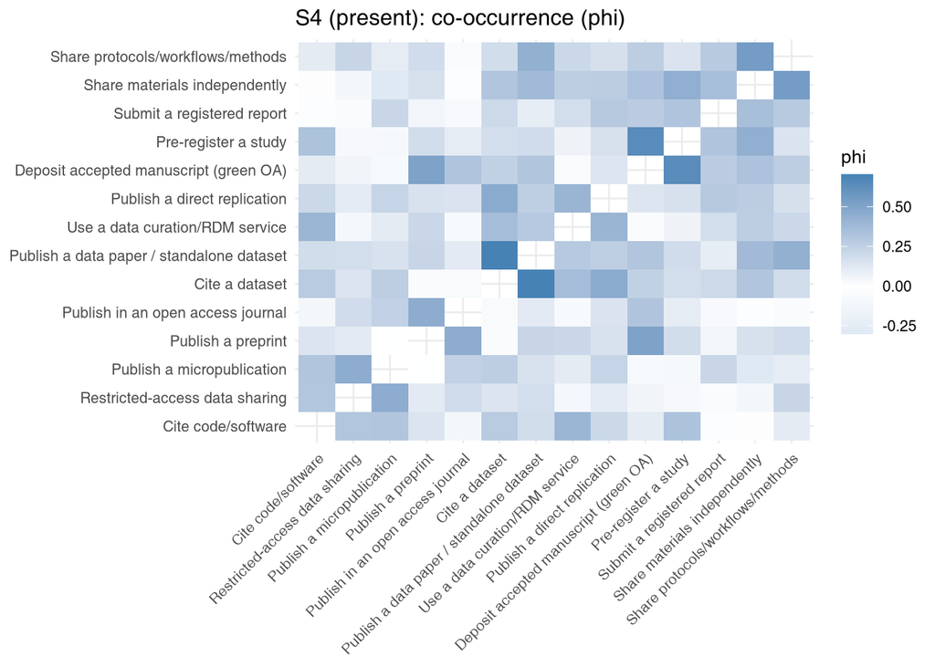

[output not shown]

### 6b) “Gateway” rules (support / confidence / lift)

**Goal:** identify potentially “gateway-like” relationships among practices (purely descriptive).

For each ordered pair A→B (two S4 items), we compute:

- support = P(A = 1 and B = 1)
- confidence = P(B = 1 | A = 1)
- lift = confidence / P(B = 1)

We restrict to rules with support ≥ 0.10 to avoid extremely rare co-occurrences.

[output not shown]

## 7) Stability-based dredging (bootstrap “which predictors keep showing up?”)

**What analysis is this?** A nonparametric “stability” check for correlation-based dredging.

For a chosen outcome (e.g., `data_shared_ever`), we:

1. Compute Spearman correlations between the outcome and each predictor (full sample) → `rho`.
2. Repeat B times (bootstrap resampling respondents with replacement):
   - recompute the correlations,
   - rank predictors by |rho|,
   - keep the top `top_k` predictors.
3. For each predictor, compute `pick_freq` = proportion of bootstrap runs where it appears in the top `top_k`.

Interpretation: high `pick_freq` means the predictor is *consistently among the strongest correlates* under resampling (still exploratory, not causal).

| outcome | pred | pick_freq | rho |
| --- | --- | --- | --- |
| Attrition share = attrition/(attrition+published) | Barrier subscale: external restrictions/policy | 0.72 | 0.37 |
| Attrition share = attrition/(attrition+published) | Mean barriers to sharing/publishing | 0.67 | 0.34 |
| Attrition share = attrition/(attrition+published) | Barrier subscale: defensive concerns (IP/misuse/competition) | 0.60 | 0.33 |
| Attrition share = attrition/(attrition+published) | Methods/statistics courses completed | 0.52 | 0.30 |
| Attrition share = attrition/(attrition+published) | Years active in experimental philosophy | 0.38 | -0.25 |
| Attrition share = attrition/(attrition+published) | Mean perceived severity of consequences | 0.37 | -0.25 |
| Attrition share = attrition/(attrition+published) | Barrier subscale: time/incentives/pressure | 0.27 | 0.22 |
| Attrition share = attrition/(attrition+published) | Mean training need for data sharing | 0.27 | 0.22 |
| Attrition share = attrition/(attrition+published) | Peer-reviewed publications per year | 0.21 | -0.20 |
| Attrition share = attrition/(attrition+published) | Barrier subscale: skills/technical barriers | 0.17 | 0.18 |
| Ever shared data | Barrier subscale: defensive concerns (IP/misuse/competition) | 0.99 | -0.53 |
| Ever shared data | Projects per year | 0.76 | 0.39 |
| Ever shared data | Quantitative projects per year | 0.75 | 0.39 |
| Ever shared data | Mean barriers to sharing/publishing | 0.72 | -0.39 |
| Ever shared data | Barrier subscale: skills/technical barriers | 0.55 | -0.34 |
| Ever shared data | Peer-reviewed publications per year | 0.38 | 0.30 |
| Ever shared data | Sponsor requirements for open dissemination (count) | 0.26 | 0.23 |
| Ever shared data | Mean motivating incentives | 0.20 | -0.25 |
| Ever shared data | Years active in experimental philosophy | 0.09 | 0.12 |
| Ever shared data | Barrier subscale: time/incentives/pressure | 0.05 | -0.20 |
| Current open-science uptake (proportion) | Projects per year | 0.95 | 0.54 |
| Current open-science uptake (proportion) | Barrier subscale: skills/technical barriers | 0.77 | -0.43 |
| Current open-science uptake (proportion) | Quantitative projects per year | 0.60 | 0.38 |
| Current open-science uptake (proportion) | Mean familiarity with consequences | 0.47 | 0.33 |
| Current open-science uptake (proportion) | Peer-reviewed publications per year | 0.40 | 0.33 |
| Current open-science uptake (proportion) | Mean barriers to sharing/publishing | 0.37 | -0.33 |
| Current open-science uptake (proportion) | Barrier subscale: time/incentives/pressure | 0.36 | -0.32 |
| Current open-science uptake (proportion) | Sponsor requirements for open dissemination (count) | 0.24 | 0.25 |
| Current open-science uptake (proportion) | Career stage (ordinal) | 0.23 | 0.23 |
| Current open-science uptake (proportion) | Mean training need for data sharing | 0.18 | -0.23 |

## 8) File-drawer pathway typology (R1 + R2–R6)

**What analysis is this?** A crude typology of “why projects stop” among respondents who report any attrition.

- We first restrict to respondents with `attrition_total_n > 0`.
- For the stage-specific reason items (R2–R6), responses are strings like `"Yes"`, `"No"`, and `"N/A"`.
  - We recode `"Yes"` → 1 and everything else → 0 (treating `"N/A"` as “not selected”).
- We then map each reason item into a coarse category:
  - results-independent (resources/interest; more studies needed)
  - quality/concerns
  - results-dependent (null; unimportant/unanticipated; unimportant by editor/reviewers)
  - structural (journal fit/scope)
- For each respondent, we count how many items they selected in each category and label the category with the highest count as `dominant`.

This is intentionally reductive (multi-select reasons are collapsed into a single dominant label) and should be treated as a descriptive device.

| dominant | n |
| --- | --- |
| Quality/concerns | 21 |
| Results-independent (more studies needed) | 6 |
| Results-dependent (null) | 5 |
| Results-independent (resources/interest) | 3 |
| Results-dependent (unimportant/unanticipated) | 2 |

| dominant | n | open_science_present_prop | data_shared_ever | attrition_total_n |
| --- | --- | --- | --- | --- |
| Quality/concerns | 21 | 0.49 | 0.90 | 6.67 |
| Results-independent (more studies needed) | 6 | 0.44 | 0.83 | 4.67 |
| Results-dependent (null) | 5 | 0.47 | 0.80 | 3.20 |
| Results-independent (resources/interest) | 3 | 0.44 | 0.67 | 5.33 |
| Results-dependent (unimportant/unanticipated) | 2 | 0.54 | 1.00 | 4.00 |

## 9) Open text dredging (lightweight regex coding)

**What analysis is this?** A minimal “keyword flagging” pass over the open-text fields.

- We concatenate multiple open text columns (S3 comments, S5 “Other”, venues, final comments, etc.) into one `text_all` string per row in the public *text-only* dataset.
- We then create binary flags for platform mentions (e.g., OSF) and theme keywords (e.g., “time/effort”) using regex patterns.
- Outputs:
  - a prevalence table (how many respondents mention each keyword/theme)
  - (no correlations in the public report; see note below)

Because mentions are sparse, many flags will have near-zero variance; treat this as a coarse exploratory supplement, not a robust text analysis.

| flag | n | pct |
| --- | --- | --- |
| mention_philarchive | 19.00 | 38.00 |
| mention_arxiv | 19.00 | 38.00 |
| mention_osf | 15.00 | 30.00 |
| theme_time_effort | 5.00 | 10.00 |
| theme_journals_review | 4.00 | 8.00 |
| mention_ssrn | 3.00 | 6.00 |
| mention_researchgate | 3.00 | 6.00 |
| theme_incentives | 3.00 | 6.00 |
| mention_github | 1.00 | 2.00 |
| mention_jasnh | 1.00 | 2.00 |
| theme_fear_criticism | 1.00 | 2.00 |
| mention_academia | 0.00 | 0.00 |
| mention_zenodo_figshare | 0.00 | 0.00 |
| theme_ip_misuse | 0.00 | 0.00 |

*Note.* In the public release, open-text responses are distributed as a separate, **unlinked** dataset; therefore, we do not compute respondent-level correlations between text flags and the main survey variables here.